# Part I: Exploratory Data Analysis - Prosper Loan

## Introduction

> The Prosper loan dataset contains 113,937 observations with 81 loan attributes and information on peer to peer loans facilitated by Prosper credit company. **What factors affect the borrower's APR or interest rate?** stands as a point of interest to me and as such I will be exploring the factors that influence interest rates to further understand how credit companies like Prosper credit arrive at those figures. As earlier observed, there are 81 loan attributes but we shall narrow down to 13 attributes that will aid this investigation effectively. Reference will be made to the data dictionary available on the link below to aid selection of the features of interest. Link: https://docs.google.com/spreadsheets/d/1gDyi_L4UvIrLTEC6Wri5nbaMmkGmLQBk-Yx3z0XDEtI/edit#gid=0

## Preliminary Wrangling

```python
#importing the necessary libraries
import pandas as pd
import numpy as np
#visualization libs
import matplotlib.pyplot as plt
%matplotlib inline
import seaborn as sns
sns.set()

import warnings
warnings.filterwarnings('ignore')
```

```python
#loading the dataset into a dataframe
loan_data = pd.read_csv('prosperLoanData.csv')
```

```python
#checking how the data looks like
loan_data.head()
```

|  | ListingKey | ListingNumber | ListingCreationDate | CreditGrade | Term | LoanStatus | ClosedDate | BorrowerAPR | BorrowerRate | LenderYield | ... | LP_ServiceFees | LP_CollectionFees | LP_GrossPrincipalLoss | LP_NetPrincipalLoss | LP_NonPrincipalRecoverypayments | PercentFunded | Recommendations | InvestmentFromFriendsCount | InvestmentFromFriendsAmount | Investors |
| --- | --- | --- | --- | --- | --- | --- | --- | --- | --- | --- | --- | --- | --- | --- | --- | --- | --- | --- | --- | --- | --- |
| 0 | 1021339766868145413AB3B | 193129 | 2007-08-26 19:09:29.263000000 | C | 36 | Completed | 2009-08-14 00:00:00 | 0.16516 | 0.1580 | 0.1380 | ... | -133.18 | 0.0 | 0.0 | 0.0 | 0.0 | 1.0 | 0 | 0 | 0.0 | 258 |
| 1 | 10273602499503308B223C1 | 1209647 | 2014-02-27 08:28:07.900000000 | NaN | 36 | Current | NaN | 0.12016 | 0.0920 | 0.0820 | ... | 0.00 | 0.0 | 0.0 | 0.0 | 0.0 | 1.0 | 0 | 0 | 0.0 | 1 |
| 2 | 0EE9337825851032864889A | 81716 | 2007-01-05 15:00:47.090000000 | HR | 36 | Completed | 2009-12-17 00:00:00 | 0.28269 | 0.2750 | 0.2400 | ... | -24.20 | 0.0 | 0.0 | 0.0 | 0.0 | 1.0 | 0 | 0 | 0.0 | 41 |
| 3 | 0EF5356002482715299901A | 658116 | 2012-10-22 11:02:35.010000000 | NaN | 36 | Current | NaN | 0.12528 | 0.0974 | 0.0874 | ... | -108.01 | 0.0 | 0.0 | 0.0 | 0.0 | 1.0 | 0 | 0 | 0.0 | 158 |
| 4 | 0F023589499656230C5E3E2 | 909464 | 2013-09-14 18:38:39.097000000 | NaN | 36 | Current | NaN | 0.24614 | 0.2085 | 0.1985 | ... | -60.27 | 0.0 | 0.0 | 0.0 | 0.0 | 1.0 | 0 | 0 | 0.0 | 20 |

5 rows × 81 columns

```python
#looking at the summary info for the dataset
loan_data.info()
```

```
<class 'pandas.core.frame.DataFrame'>
RangeIndex: 113937 entries, 0 to 113936
Data columns (total 81 columns):
 #   Column                               Non-Null Count   Dtype
---  ------                               --------------   -----
 0   ListingKey                           113937 non-null  object
 1   ListingNumber                        113937 non-null  int64
 2   ListingCreationDate                  113937 non-null  object
 3   CreditGrade                          28953 non-null   object
 4   Term                                 113937 non-null  int64
 5   LoanStatus                           113937 non-null  object
 6   ClosedDate                           55089 non-null   object
 7   BorrowerAPR                          113912 non-null  float64
 8   BorrowerRate                         113937 non-null  float64
 9   LenderYield                          113937 non-null  float64
```

[output cut: 73 more lines]

We can see that there are some categorical and numerical features with some of the features having missing values.

```python
#summary stats for the dataset
loan_data.describe()
```

|  | ListingNumber | Term | BorrowerAPR | BorrowerRate | LenderYield | EstimatedEffectiveYield | EstimatedLoss | EstimatedReturn | ProsperRating (numeric) | ProsperScore | ... | LP_ServiceFees | LP_CollectionFees | LP_GrossPrincipalLoss | LP_NetPrincipalLoss | LP_NonPrincipalRecoverypayments | PercentFunded | Recommendations | InvestmentFromFriendsCount | InvestmentFromFriendsAmount | Investors |
| --- | --- | --- | --- | --- | --- | --- | --- | --- | --- | --- | --- | --- | --- | --- | --- | --- | --- | --- | --- | --- | --- |
| count | 1.139370e+05 | 113937.000000 | 113912.000000 | 113937.000000 | 113937.000000 | 84853.000000 | 84853.000000 | 84853.000000 | 84853.000000 | 84853.000000 | ... | 113937.000000 | 113937.000000 | 113937.000000 | 113937.000000 | 113937.000000 | 113937.000000 | 113937.000000 | 113937.000000 | 113937.000000 | 113937.000000 |
| mean | 6.278857e+05 | 40.830248 | 0.218828 | 0.192764 | 0.182701 | 0.168661 | 0.080306 | 0.096068 | 4.072243 | 5.950067 | ... | -54.725641 | -14.242698 | 700.446342 | 681.420499 | 25.142686 | 0.998584 | 0.048027 | 0.023460 | 16.550751 | 80.475228 |
| std | 3.280762e+05 | 10.436212 | 0.080364 | 0.074818 | 0.074516 | 0.068467 | 0.046764 | 0.030403 | 1.673227 | 2.376501 | ... | 60.675425 | 109.232758 | 2388.513831 | 2357.167068 | 275.657937 | 0.017919 | 0.332353 | 0.232412 | 294.545422 | 103.239020 |
| min | 4.000000e+00 | 12.000000 | 0.006530 | 0.000000 | -0.010000 | -0.182700 | 0.004900 | -0.182700 | 1.000000 | 1.000000 | ... | -664.870000 | -9274.750000 | -94.200000 | -954.550000 | 0.000000 | 0.700000 | 0.000000 | 0.000000 | 0.000000 | 1.000000 |
| 25% | 4.009190e+05 | 36.000000 | 0.156290 | 0.134000 | 0.124200 | 0.115670 | 0.042400 | 0.074080 | 3.000000 | 4.000000 | ... | -73.180000 | 0.000000 | 0.000000 | 0.000000 | 0.000000 | 1.000000 | 0.000000 | 0.000000 | 0.000000 | 2.000000 |
| 50% | 6.005540e+05 | 36.000000 | 0.209760 | 0.184000 | 0.173000 | 0.161500 | 0.072400 | 0.091700 | 4.000000 | 6.000000 | ... | -34.440000 | 0.000000 | 0.000000 | 0.000000 | 0.000000 | 1.000000 | 0.000000 | 0.000000 | 0.000000 | 44.000000 |
| 75% | 8.926340e+05 | 36.000000 | 0.283810 | 0.250000 | 0.240000 | 0.224300 | 0.112000 | 0.116600 | 5.000000 | 8.000000 | ... | -13.920000 | 0.000000 | 0.000000 | 0.000000 | 0.000000 | 1.000000 | 0.000000 | 0.000000 | 0.000000 | 115.000000 |
| max | 1.255725e+06 | 60.000000 | 0.512290 | 0.497500 | 0.492500 | 0.319900 | 0.366000 | 0.283700 | 7.000000 | 11.000000 | ... | 32.060000 | 0.000000 | 25000.000000 | 25000.000000 | 21117.900000 | 1.012500 | 39.000000 | 33.000000 | 25000.000000 | 1189.000000 |

8 rows × 61 columns

### Variable Selection

For this analysis, we shall be subsetting the dataset by selecting 13 features of interest as seen below;

```python
#creating a subset of loan_data with 15 features
loan_data_sub = loan_data[['Term', 'LoanStatus', 'BorrowerAPR', 'ProsperScore', 'ListingCategory (numeric)', 'EmploymentStatus',
                    'EmploymentStatusDuration', 'IsBorrowerHomeowner', 'DebtToIncomeRatio', 'StatedMonthlyIncome', 'LoanOriginalAmount',
                    'LoanOriginationDate', 'MonthlyLoanPayment']]
#displaying the new dataframe
loan_data_sub.head()
```

|  | Term | LoanStatus | BorrowerAPR | ProsperScore | ListingCategory (numeric) | EmploymentStatus | EmploymentStatusDuration | IsBorrowerHomeowner | DebtToIncomeRatio | StatedMonthlyIncome | LoanOriginalAmount | LoanOriginationDate | MonthlyLoanPayment |
| --- | --- | --- | --- | --- | --- | --- | --- | --- | --- | --- | --- | --- | --- |
| 0 | 36 | Completed | 0.16516 | NaN | 0 | Self-employed | 2.0 | True | 0.17 | 3083.333333 | 9425 | 2007-09-12 00:00:00 | 330.43 |
| 1 | 36 | Current | 0.12016 | 7.0 | 2 | Employed | 44.0 | False | 0.18 | 6125.000000 | 10000 | 2014-03-03 00:00:00 | 318.93 |
| 2 | 36 | Completed | 0.28269 | NaN | 0 | Not available | NaN | False | 0.06 | 2083.333333 | 3001 | 2007-01-17 00:00:00 | 123.32 |
| 3 | 36 | Current | 0.12528 | 9.0 | 16 | Employed | 113.0 | True | 0.15 | 2875.000000 | 10000 | 2012-11-01 00:00:00 | 321.45 |
| 4 | 36 | Current | 0.24614 | 4.0 | 2 | Employed | 44.0 | True | 0.26 | 9583.333333 | 15000 | 2013-09-20 00:00:00 | 563.97 |

We can see that we have successfully seleected the features of interest from the large dataset

```python
#summary info for the subset dataset
loan_data_sub.info()
```

```
<class 'pandas.core.frame.DataFrame'>
RangeIndex: 113937 entries, 0 to 113936
Data columns (total 13 columns):
 #   Column                     Non-Null Count   Dtype
---  ------                     --------------   -----
 0   Term                       113937 non-null  int64
 1   LoanStatus                 113937 non-null  object
 2   BorrowerAPR                113912 non-null  float64
 3   ProsperScore               84853 non-null   float64
 4   ListingCategory (numeric)  113937 non-null  int64
 5   EmploymentStatus           111682 non-null  object
 6   EmploymentStatusDuration   106312 non-null  float64
 7   IsBorrowerHomeowner        113937 non-null  bool
 8   DebtToIncomeRatio          105383 non-null  float64
 9   StatedMonthlyIncome        113937 non-null  float64
 10  LoanOriginalAmount         113937 non-null  int64
 11  LoanOriginationDate        113937 non-null  object
 12  MonthlyLoanPayment         113937 non-null  float64
dtypes: bool(1), float64(6), int64(3), object(3)
memory usage: 10.5+ MB
```

We can see that BorrowerAPR, ProsperScore, EmploymentStatus, EmploymentStatusDuration, and DebtToIncomeRatio have some missing values. We shall further investigate and handle these in the data cleaning phase.

### Data Cleaning

Some of the issues that are going to be handled in this phase are:

> - Dealing with missing values for the identified features
> - Renaming the ListingCategory (numeric) feature to ListingCategory
> - Changing the LoanOriginationDate feature type from string to datetime

```python
#confirming presence of missing values
loan_data_sub.isna().sum()
```

```
Term                             0
LoanStatus                       0
BorrowerAPR                     25
ProsperScore                 29084
ListingCategory (numeric)        0
EmploymentStatus              2255
EmploymentStatusDuration      7625
IsBorrowerHomeowner              0
DebtToIncomeRatio             8554
StatedMonthlyIncome              0
LoanOriginalAmount               0
LoanOriginationDate              0
MonthlyLoanPayment               0
dtype: int64
```

```python
#checking for duplicates
loan_data_sub.duplicated().sum()
```

```
0
```

We can see that there are no duplicates in order dataset

```python
#investigating the EmploymentStatus feature
#percentage of missing values
print(f'{(loan_data_sub.EmploymentStatus.isna().sum()/len(loan_data_sub.EmploymentStatus))*100}%')
```

```
1.9791639239228696%
```

We can see that the percentage of observations missing values in the EmploymentStatus is about 1.98 and so we shall drop these observations as this will not significantly affect our analysis.

```python
#filling missing values
#ProsperScore will be filled with zeros to signal lack of a score
loan_data_sub.ProsperScore = loan_data_sub.ProsperScore.fillna(0)
#filling BorrowerAPR with the mean for that feature
loan_data_sub.BorrowerAPR = loan_data_sub.BorrowerAPR.fillna(np.mean(loan_data_sub.BorrowerAPR))
#filling the DebtToIncomeRatio featire with zero following feature description
loan_data_sub.DebtToIncomeRatio = loan_data_sub.DebtToIncomeRatio.fillna(0)
#filling the EmploymentStatusDuration with the mean
loan_data_sub.EmploymentStatusDuration = loan_data_sub.EmploymentStatusDuration.fillna(np.mean(loan_data_sub.EmploymentStatusDuration))
```

```python
#dropping observations with missing values in the EmploymentStatus feature
loan_data_sub.dropna(inplace=True)
#checking if the changes have been successfully effected
loan_data_sub.info()
```

```
<class 'pandas.core.frame.DataFrame'>
Int64Index: 111682 entries, 0 to 113936
Data columns (total 13 columns):
 #   Column                     Non-Null Count   Dtype
---  ------                     --------------   -----
 0   Term                       111682 non-null  int64
 1   LoanStatus                 111682 non-null  object
 2   BorrowerAPR                111682 non-null  float64
 3   ProsperScore               111682 non-null  float64
 4   ListingCategory (numeric)  111682 non-null  int64
 5   EmploymentStatus           111682 non-null  object
 6   EmploymentStatusDuration   111682 non-null  float64
 7   IsBorrowerHomeowner        111682 non-null  bool
 8   DebtToIncomeRatio          111682 non-null  float64
 9   StatedMonthlyIncome        111682 non-null  float64
 10  LoanOriginalAmount         111682 non-null  int64
 11  LoanOriginationDate        111682 non-null  object
 12  MonthlyLoanPayment         111682 non-null  float64
dtypes: bool(1), float64(6), int64(3), object(3)
memory usage: 11.2+ MB
```

We now have a complete dataset so we shall proceed to enaming the ListingCategory (numeric) feature to ListingCategory.

```python
#Renaming the ListingCategory (numeric) feature to ListingCategory
loan_data_sub.rename(columns={'ListingCategory (numeric)' : 'ListingCategory'}, inplace=True)
loan_data_sub.columns
```

```
Index(['Term', 'LoanStatus', 'BorrowerAPR', 'ProsperScore', 'ListingCategory',
       'EmploymentStatus', 'EmploymentStatusDuration', 'IsBorrowerHomeowner',
       'DebtToIncomeRatio', 'StatedMonthlyIncome', 'LoanOriginalAmount',
       'LoanOriginationDate', 'MonthlyLoanPayment'],
      dtype='object')
```

```python
loan_data_sub.LoanStatus.unique()
```

```
array(['Completed', 'Current', 'Past Due (1-15 days)', 'Defaulted',
       'Chargedoff', 'Past Due (16-30 days)', 'Past Due (61-90 days)',
       'Past Due (31-60 days)', 'Past Due (91-120 days)',
       'FinalPaymentInProgress', 'Past Due (>120 days)', 'Cancelled'],
      dtype=object)
```

We can see that the feature has been renamed

```python
#changing the data type of LoanOriginationDate feature to datetime
loan_data_sub.LoanOriginationDate = loan_data_sub.LoanOriginationDate.astype('datetime64')
#resetting index for the dataset
loan_data_sub = loan_data_sub.reset_index(drop=True)
#checking for changes
loan_data_sub.info()
```

```
<class 'pandas.core.frame.DataFrame'>
RangeIndex: 111682 entries, 0 to 111681
Data columns (total 13 columns):
 #   Column                    Non-Null Count   Dtype
---  ------                    --------------   -----
 0   Term                      111682 non-null  int64
 1   LoanStatus                111682 non-null  object
 2   BorrowerAPR               111682 non-null  float64
 3   ProsperScore              111682 non-null  float64
 4   ListingCategory           111682 non-null  int64
 5   EmploymentStatus          111682 non-null  object
 6   EmploymentStatusDuration  111682 non-null  float64
 7   IsBorrowerHomeowner       111682 non-null  bool
 8   DebtToIncomeRatio         111682 non-null  float64
 9   StatedMonthlyIncome       111682 non-null  float64
 10  LoanOriginalAmount        111682 non-null  int64
 11  LoanOriginationDate       111682 non-null  datetime64[ns]
 12  MonthlyLoanPayment        111682 non-null  float64
dtypes: bool(1), datetime64[ns](1), float64(6), int64(3), object(2)
memory usage: 10.3+ MB
```

We now have a clean dataset so we shall proceed to doing our analysis

```python
#saving the clean dataset to a csv file
loan_data_sub.to_csv('loan_data_cleaned.csv', index=False)
```

### What is the structure of your dataset?

> The Prosper loan dataset contains 113,937 observations with 81 loan attributes. 13 of the 81 original attributes have been selected for all observations for this analysis. After the data cleaning phase, we have 111682 observations to analyze.

### What is/are the main feature(s) of interest in your dataset?

> The main feature of interest in the subset dataset is the BorrowerAPR feature.

### What features in the dataset do you think will help support your investigation into your feature(s) of interest?

> The features that will help support the investigation into the Borrowers APR are Term, LoanStatus, BorrowerAPR, ProsperScore, ListingCategory, EmploymentStatus,EmploymentStatusDuration, IsBorrowerHomeowner, DebtToIncomeRatio, StatedMonthlyIncome, LoanOriginalAmount, LoanOriginationDate, and MonthlyLoanPayment.

## Univariate Exploration

> Here , we will look at the distributions of all features individually.

### 1. What is the distribution of the BorrowerAPR feature?

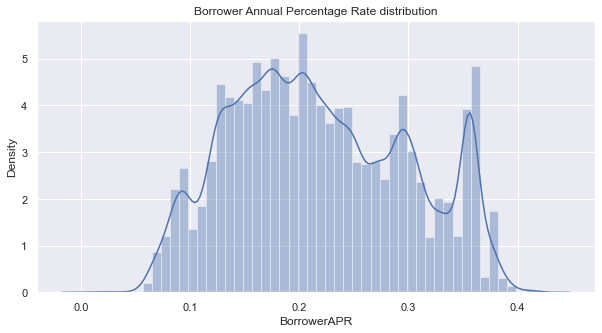

```python
#Distribution of Borrower APR
plt.figure(figsize=(10,5))
sns.distplot(loan_data_sub.BorrowerAPR).set(title='Borrower Annual Percentage Rate distribution');
```

Observation: From the distplot above, Borrower Annual Percentage Rate distribution seems to have more than one mode and a thus we can conclude that its multimodal

### 2. What is the percentage distribution of loans by term?

```python
#grouping the data by terms
term_groups = loan_data_sub.groupby('Term')
#extracting unique terms from the Term feature
terms = loan_data_sub.Term.unique()
#dictionary of stats by term
stats = {}
for level in terms:
    print(f'{level}: {term_groups.get_group(level).shape[0]}')
    stats[level] = term_groups.get_group(level).shape[0]
```

```
36: 85523
60: 24545
12: 1614
```

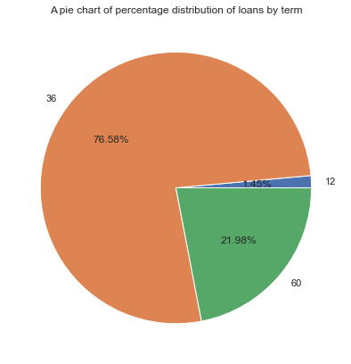

```python
# sorted by key, return a list of tuples
lists = sorted(stats.items())
# unpack a list of pairs into two tuples
x, y = zip(*lists)
plt.figure(figsize=(10,7))
plt.pie(y, labels=x,autopct='%1.2f%%')
plt.title("A pie chart of percentage distribution of loans by term");
```

Observation: We can observe that the loans to be paid in 36 months account for 76.58% of all loans followed by loans to be paid in 60 months at 21.98% and finally loans to be paid in a year at 1.45%. This shows that Prosper credit company majorly offers midterm loans as oppossed to short or longterm loans

### 3. What is the most frequently loaned amount?

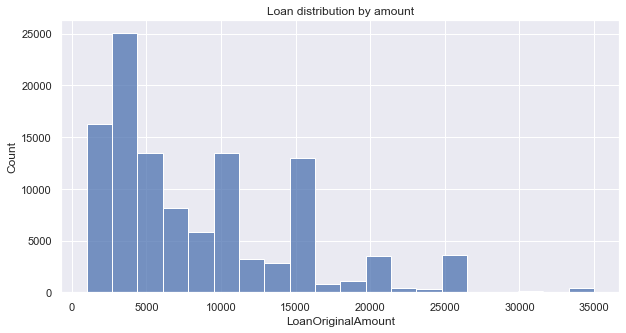

```python
#Loan distribution by amount
plt.figure(figsize=(10,5))
sns.histplot(loan_data_sub.LoanOriginalAmount, bins=20).set(title="Loan distribution by amount");
```

```python
#retrieving the amount with the highest frequency
most_awarded = loan_data_sub.LoanOriginalAmount.value_counts().idxmax()
most_awarded
```

```
4000
```

Observation: We can see that the loan amounts are right skewed and that the most frequently offered loan amount is $4k

### 4. What is the distribution of loans by loan status?

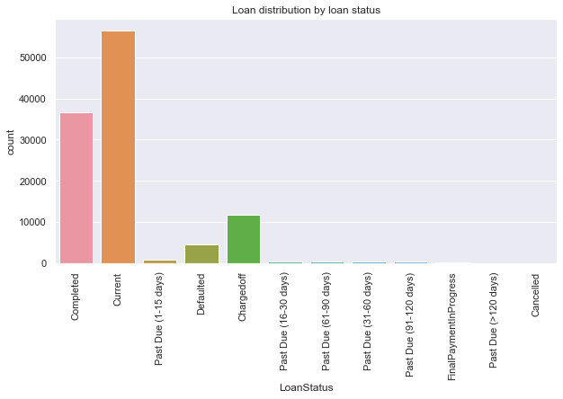

```python
plt.figure(figsize=(10,5))
sns.countplot(data = loan_data_sub, x ='LoanStatus').set(title="Loan distribution by loan status")
plt.xticks(rotation = 90);
```

Observation: Most of the loans are in current status with another sizeable number of loans in completed status.

### 5. What is the distribution of loans by employment status?

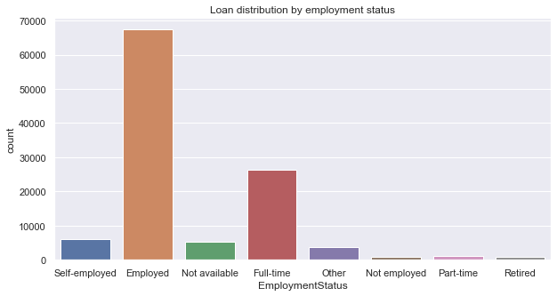

```python
plt.figure(figsize=(10,5))
sns.countplot(data = loan_data_sub, x = 'EmploymentStatus').set(title="Loan distribution by employment status");
```

Observation: Employment status categories are Self-employed, Employed, Not available, Full-time, Other, Not employed, Part-time, and Retired with the Employed people taking up most of the loans.

### 6. What is the distribution of loans by listing category?

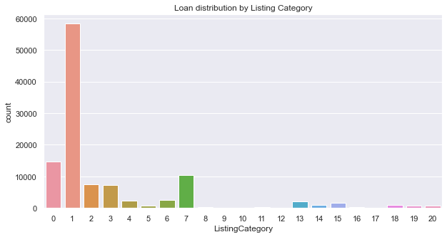

```python
plt.figure(figsize=(10,5))
sns.countplot(data = loan_data_sub, x = 'ListingCategory').set(title="Loan distribution by Listing Category");
```

Observation: The most frequentlyloan category applied for is Debt Consolidation(1).

### 7. Distribution of Stated Monthly income

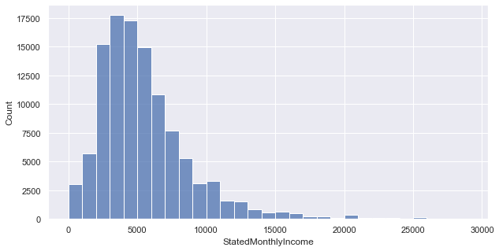

```python
plt.figure(figsize=(10,5))
bins = np.arange(0,30000,1000)
sns.histplot(data=loan_data_sub, x='StatedMonthlyIncome', bins= bins);
```

Observation: The borrowers monthly income is right skewed with the most frequent monthly income being close to $4200

### Discuss the distribution(s) of your variable(s) of interest. Were there any unusual points? Did you need to perform any transformations?

> The Borrower Annual Percentage Rate distribution seems to have more than one mode and thus we can conclude that its multimodal

### Of the features you investigated, were there any unusual distributions? Did you perform any operations on the data to tidy, adjust, or change the form of the data? If so, why did you do this?

> - We can observe that the loans to be paid in 36 months account for 76.58% of all loans followed by loans to be paid in 60 months at 21.98% and finally loans to be paid in a year at 1.45%. This shows that Prosper credit company majorly offers midterm loans as oppossed to short or longterm loans.
> - We can see that the loan amounts are right skewed and that the most frequently offered loan amount is $4k
> - Most of the loans are in current status with another sizeable number of loans in completed status.
> - Employment status categories are Self-employed, Employed, Not available, Full-time, Other, Not employed, Part-time, and Retired with the Employed people taking up most of the loans.
> - The most frequentlyloan category applied for is Debt Consolidation(1).
> - The borrowers monthly income is right skewed with the most frequent monthly income being close to \$4200

## Bivariate Exploration

Here, we shall investigate the relationship between features, considering two features at a time.

```python
#we shall look at the feature correlation
correlation_matrix = loan_data_sub.corr()
correlation_matrix
```

|  | Term | BorrowerAPR | ProsperScore | ListingCategory | EmploymentStatusDuration | IsBorrowerHomeowner | DebtToIncomeRatio | StatedMonthlyIncome | LoanOriginalAmount | MonthlyLoanPayment |
| --- | --- | --- | --- | --- | --- | --- | --- | --- | --- | --- |
| Term | 1.000000 | -0.013997 | 0.221895 | -0.001550 | 0.082015 | 0.081809 | -0.010000 | 0.028080 | 0.336733 | 0.086480 |
| BorrowerAPR | -0.013997 | 1.000000 | -0.239232 | 0.130206 | -0.008426 | -0.135988 | 0.037260 | -0.081111 | -0.329469 | -0.232603 |
| ProsperScore | 0.221895 | -0.239232 | 1.000000 | 0.159744 | 0.100189 | 0.088300 | -0.083676 | 0.108017 | 0.295006 | 0.216145 |
| ListingCategory | -0.001550 | 0.130206 | 0.159744 | 1.000000 | -0.005473 | -0.045700 | -0.049838 | 0.000775 | -0.137377 | -0.128326 |
| EmploymentStatusDuration | 0.082015 | -0.008426 | 0.100189 | -0.005473 | 1.000000 | 0.166822 | -0.006038 | 0.068846 | 0.095899 | 0.078907 |
| IsBorrowerHomeowner | 0.081809 | -0.135988 | 0.088300 | -0.045700 | 0.166822 | 1.000000 | 0.007871 | 0.139597 | 0.203232 | 0.175855 |
| DebtToIncomeRatio | -0.010000 | 0.037260 | -0.083676 | -0.049838 | -0.006038 | 0.007871 | 1.000000 | -0.074449 | 0.015013 | 0.028455 |
| StatedMonthlyIncome | 0.028080 | -0.081111 | 0.108017 | 0.000775 | 0.068846 | 0.139597 | -0.074449 | 1.000000 | 0.200488 | 0.196157 |
| LoanOriginalAmount | 0.336733 | -0.329469 | 0.295006 | -0.137377 | 0.095899 | 0.203232 | 0.015013 | 0.200488 | 1.000000 | 0.931089 |
| MonthlyLoanPayment | 0.086480 | -0.232603 | 0.216145 | -0.128326 | 0.078907 | 0.175855 | 0.028455 | 0.196157 | 0.931089 | 1.000000 |

The correlation matrix is not easy to keep up with so we shall visualize it on a heatmap for easier understanding.

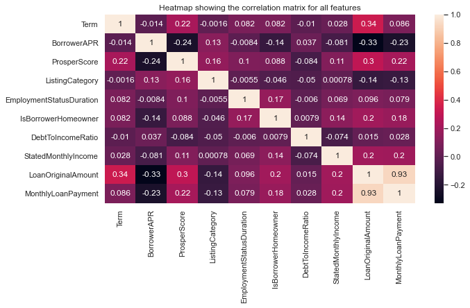

```python
#visualizing the correlation matrix
plt.figure(figsize=(10,5))
sns.heatmap(correlation_matrix, annot=True).set(title="Heatmap showing the correlation matrix for all features");
```

From the correlation heat map we can see that the existance of a strong positive correlation between LoanOriginalAmount and MonthlyLoanPayment alongside other positive correlations. WE can also see a weak negative correlation of -0.33 between BorrowerAPR and LoanOriginalAmount alongside other week negative correlations. We will further investigate these features to better understand the relationships among them.

### 1. How does the loan amount affect the monthly repayment amount?

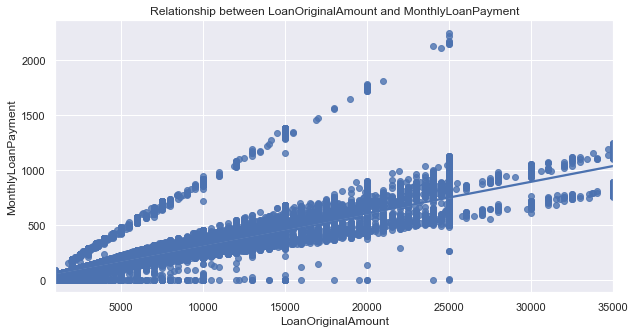

```python
plt.figure(figsize=(10,5))
sns.regplot(data=loan_data_sub, x='LoanOriginalAmount', y='MonthlyLoanPayment').set(
    title="Relationship between LoanOriginalAmount and MonthlyLoanPayment");
```

Observation: The bigger the loan amount, the bigger the monthly repayment amount. This signals a direct proportionality between loan amount and monthly loan repayment.

### 2. How does the Loan amount affect the Borrowers Annual Rate Percentage?

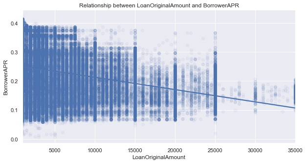

```python
plt.figure(figsize=(10,5))
sns.regplot(data=loan_data_sub, x='LoanOriginalAmount', y='BorrowerAPR',  scatter_kws={'alpha':0.05}).set(
    title="Relationship between LoanOriginalAmount and BorrowerAPR");
```

Observation: The higher the loan amount the lower the Borrowers Annual Percentage Rate.

### 3. How does loan amount vary with loan term?

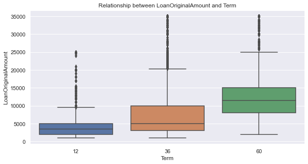

```python
plt.figure(figsize=(10,5))
sns.boxplot(data=loan_data_sub, x=loan_data_sub.Term, y=loan_data_sub.LoanOriginalAmount).set(
    title="Relationship between LoanOriginalAmount and Term");
```

Observation: Longer loan terms are given for higher loan amounts.

### 4. How does the borrower's monthly income influence loan amount applied for?

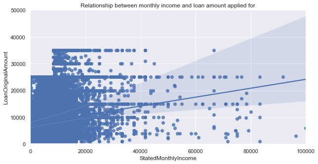

```python
plt.figure(figsize=(10,5))
lim = [[0, 100000],[0, 50000]]
plt.xlim(lim[0])
plt.ylim(lim[1])
sns.regplot(data=loan_data_sub,x='StatedMonthlyIncome', y='LoanOriginalAmount').set(
    title="Relationship between monthly income and loan amount applied for");
```

Observation: Borrowers with higher monthly income apply for loans with bigger loan amounts.

### 5. How does employment duration affect home ownership?

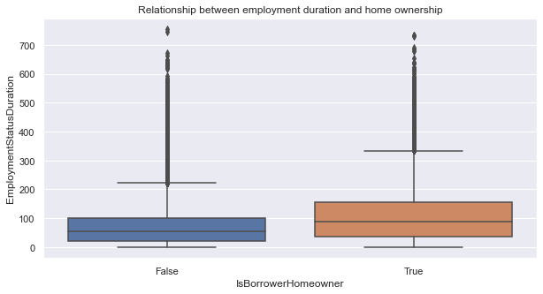

```python
plt.figure(figsize=(10,5))
sns.boxplot(data=loan_data_sub,x="IsBorrowerHomeowner", y="EmploymentStatusDuration").set(
    title="Relationship between employment duration and home ownership");
```

Observation: Borrowers with who own homes have longer employment durations.

### 6. How does monthly income influence monthly loan repayment amounts?

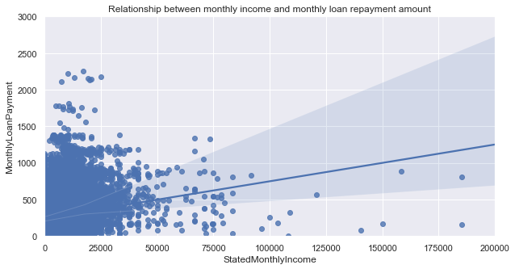

```python
plt.figure(figsize=(10,5))
lim = [[0, 200000],[0, 3000]]
plt.xlim(lim[0])
plt.ylim(lim[1])
sns.regplot(data=loan_data_sub,x='StatedMonthlyIncome', y='MonthlyLoanPayment').set(
    title="Relationship between monthly income and monthly loan repayment amount");
```

Observation: Borrowers with higher monthly income are can afford to pay higher monthly loan repayment installments.

### 7. What is the distribution of the loaned amount home ownnership?

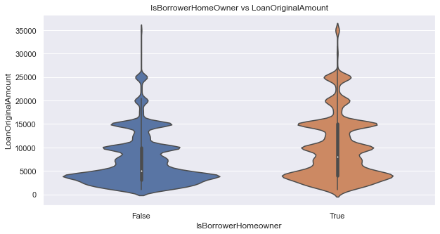

```python
plt.figure(figsize=(10,5))
sns.violinplot(x="IsBorrowerHomeowner", y="LoanOriginalAmount", data=loan_data_sub).set(
    title="IsBorrowerHomeOwner vs LoanOriginalAmount");
```

Observation: We can see that most home owner loan amounts are spread out with majority of it above $$5000 and below $5000 for most borrowers that don't own homes.

### Talk about some of the relationships you observed in this part of the investigation. How did the feature(s) of interest vary with other features in the dataset?

> The bigger the loan amount, the bigger the monthly repayment amount. This signals a direct proportionality between loan amount and monthly loan repayment.The higher the loan amount the lower the Borrowers Annual Percentage Rate. Longer loan terms are given for higher loan amounts. Borrowers with higher monthly income apply for loans with bigger loan amounts. Borrowers with who own homes have longer employment durations.

### Did you observe any interesting relationships between the other features (not the main feature(s) of interest)?

> Borrowers with higher monthly income are can afford to pay higher monthly loan repayment installments. We can see that most home owner loan amounts are spread out with majority of it above $$5000 and below $5000 for most borrowers that don't own homes.

## Multivariate Exploration

We shall be investigating more than two features at the same time to understand the possible relationships

### 1. How does the loan term affect loan amount issue and the Borrower's Annual Percentage Rate?

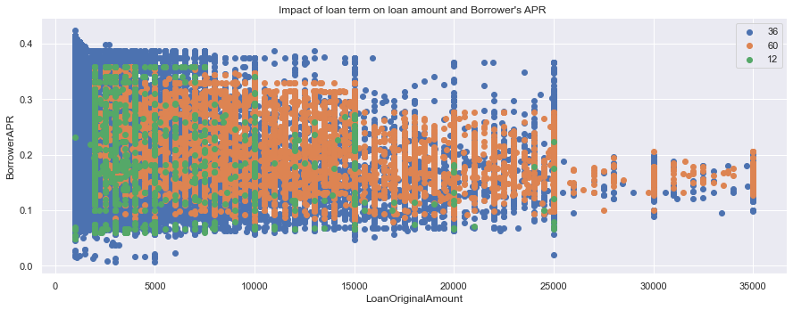

```python
order=[36, 60, 12]
_ = sns.FacetGrid(data=loan_data_sub,hue ='Term',hue_order=order,size=5,aspect=2.5).set(
    title="Impact of loan term on loan amount and Borrower's APR ")
_.map(plt.scatter, 'LoanOriginalAmount', 'BorrowerAPR')
plt.legend();
```

Observation: The 36-month term loans have borrowers annual percentage rate ranging from 0 to 0.45, 60-month term loans are concentrated more on the higher loan amounts and borrowers annual percentage rate between 0.1 and 0.35, and the 12-month loan term loans are dominantly for lower loan amounts with a borrowers annual percentage rate running between 0 and 0.35.

### 2: LoanOriginalAmount vs MonthlyLoanPayment vs Term

Question: Will the monthly loan payments for the different terms be similar?

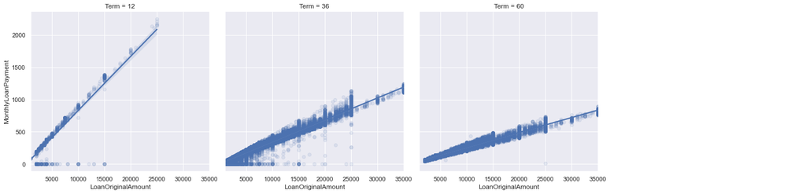

```python
_=sns.FacetGrid(data=loan_data_sub, aspect=1.0, height=5, col='Term', col_wrap=4).set(
    title="LoanOriginalAmount vs MonthlyLoanPayment vs Term")
_.map(sns.regplot, 'LoanOriginalAmount', 'MonthlyLoanPayment', x_jitter=0.04, scatter_kws={'alpha':0.1});
_.add_legend();
```

Observation: 12-month loans have greater monthly repayment installments than the others because its the shortest duration.

### Talk about some of the relationships you observed in this part of the investigation. Were there features that strengthened each other in terms of looking at your feature(s) of interest?

> - The 36-month term loans have borrowers annual percentage rate ranging from 0 to 0.45, 60-month term loans are concentrated more on the higher loan amounts and borrowers annual percentage rate between 0.1 and 0.35, and the 12-month loan term loans are dominantly for lower loan amounts with a borrowers annual percentage rate running between 0 and 0.35.

### Were there any interesting or surprising interactions between features?

> - 12-month loans have greater monthly repayment installments than the others because its the shortest duration.